# STAT462: Data Mining Assignment1

Thi Minh Nguyet Tran - 87540111

**Question 1**:

**(a) Sketch the dataset**

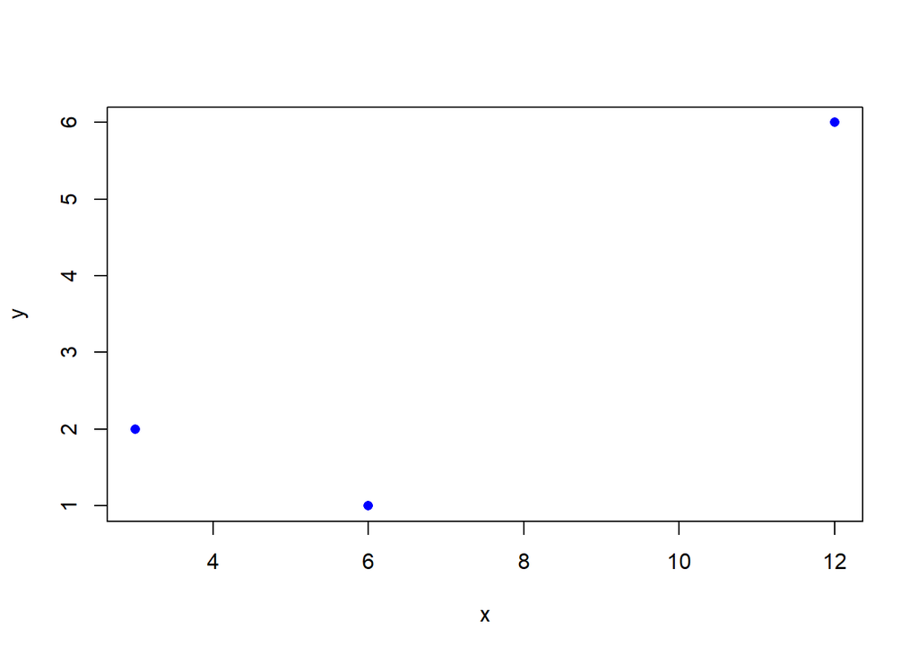

```r
#A given dataset
x <- c(3, 6, 12)
y <- c(2, 1, 6)
#Plot the dataset
plot(x, y, pch=16, col = "blue")
```

**(a) Compute beta_hat1 and beta_hat0**

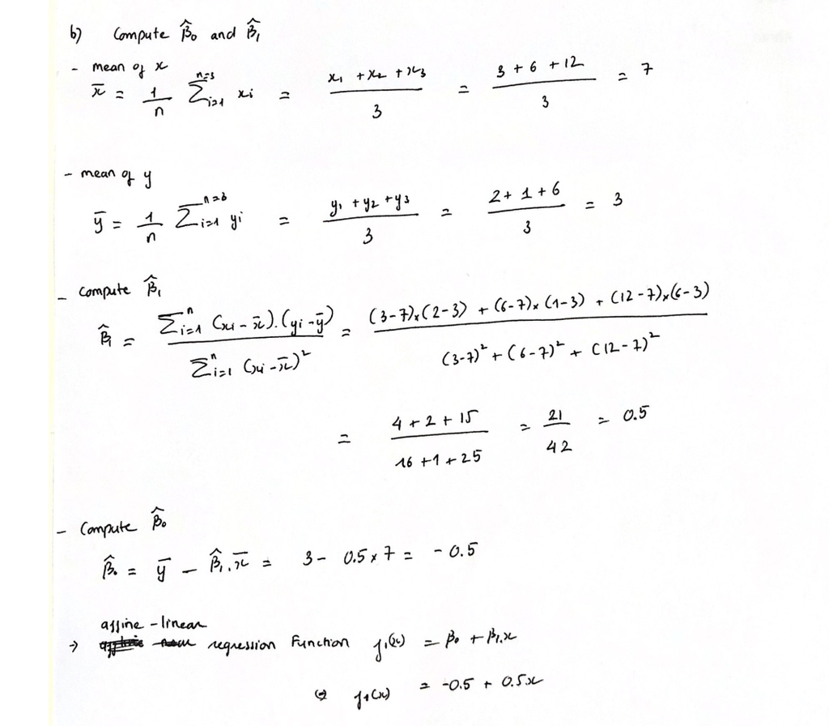

**(c) Sketch the graph of the fitted linear model jointly with the data set (continuing the figure from part (a))**

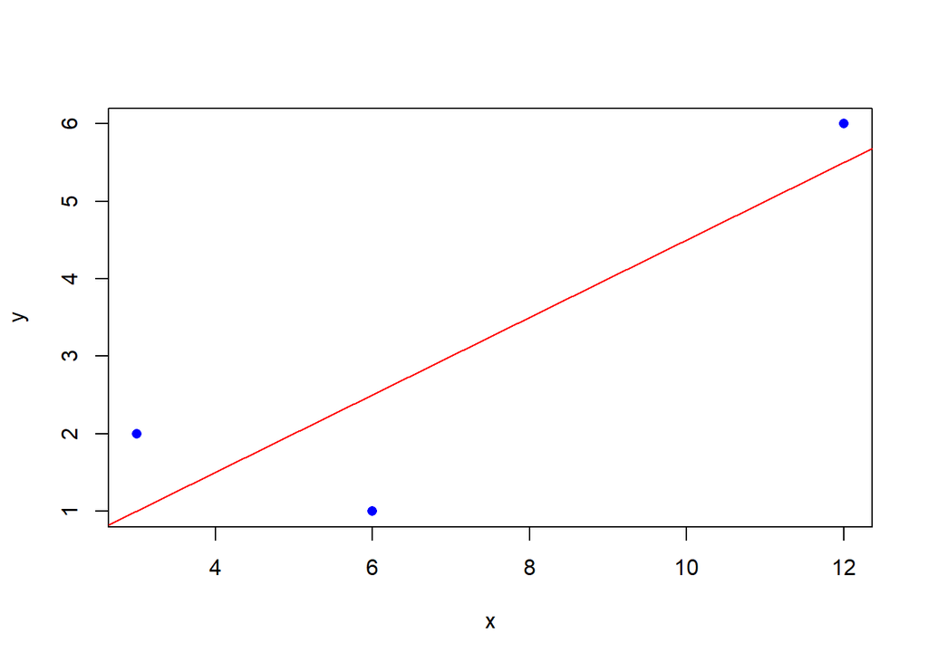

```r
data_exam <- data.frame(x, y)
plot(data_exam$x, data_exam$y, pch=16, col = "blue", xlab = "x", ylab = "y")
abline(lm(y ~ x, data = data_exam), col = "red")
```

**(d) Compute training MSE and testing MSE**

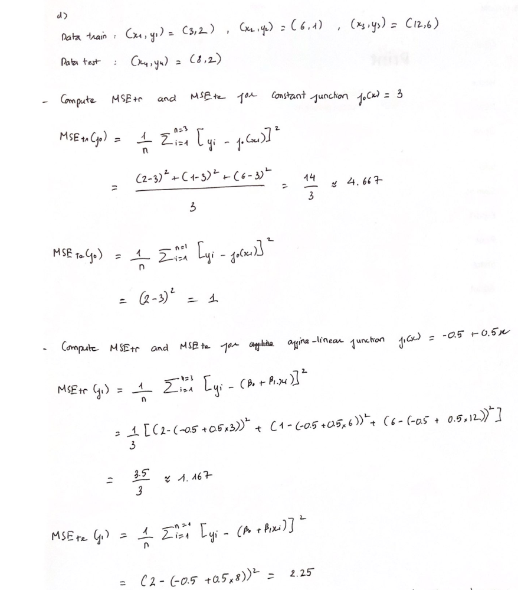

**Explain:** I will pick model f0(x). this is because the training MSE measures how well a model fits the training data, while the testing MSE measures how well the model make predictions on new data. In this case, testing MSE of f1(x) is higher than that of f0(x), indicating that model f1(x) is not able to generalize well to new data. The model with the lower MSE_test is better. Therefore, f0(x) generalizes better performance than f1(x).

```
##   Model MSE_train MSE_test
## 1 f0(x)     4.667     1.00
## 2 f1(x)     1.167     2.25
```

**Question 2**: Fit kNN regression models to the Auto data set to predict Y = horsepower using X = weight. This data has been divided into training and testing sets: AutoTrain.csv and AutoTest.csv

```r
# Input data sources
auto_test <- read.csv("AutoTest.csv")
auto_train <- read.csv("AutoTrain.csv")
head(auto_train, 5)
```

```
##     X mpg cylinders displacement horsepower weight acceleration year origin
## 1 140  29         4           98         83   2219         16.5   74      2
## 2 207  13         8          318        150   3940         13.2   76      1
## 3 174  29         4           90         70   1937         14.0   75      2
## 4 363  28         4          112         88   2605         19.6   82      1
## 5 170  24         4          134         96   2702         13.5   75      3
##                         name
## 1                   audi fox
## 2 plymouth volare premier v8
## 3          volkswagen rabbit
## 4         chevrolet cavalier
## 5              toyota corona
```

```r
head(auto_test, 5)
```

```
##    X mpg cylinders displacement horsepower weight acceleration year origin
## 1  7  14         8          454        220   4354          9.0   70      1
## 2 11  15         8          383        170   3563         10.0   70      1
## 3 13  15         8          400        150   3761          9.5   70      1
## 4 18  21         6          200         85   2587         16.0   70      1
## 5 19  27         4           97         88   2130         14.5   70      3
##                    name
## 1      chevrolet impala
## 2   dodge challenger se
## 3 chevrolet monte carlo
## 4         ford maverick
## 5          datsun pl510
```

We have X = weight is predictor and Y = horsepower is response

```r
#Training predictor values
x_train <- auto_train$weight
#Training response values
y_train <- auto_train$horsepower
#Testing predictor values
x_test <- auto_test$weight
#Testing response values
y_test <- auto_test$horsepower
#Value of k
k_values <- c(2, 5, 10, 20, 30, 50, 100)
```

Create Function to predict response values

```r
kNN <- function(k,x.train,y.train,x.pred) {
  n.pred <- length(x.pred);     y.pred <- numeric(n.pred)
  for (i in 1:n.pred){
    d <- abs(x.train - x.pred[i])
    dstar = d[order(d)[k]]
    y.pred[i] <- mean(y.train[d <= dstar])
  }
  # Return the vector of predictions
  invisible(y.pred)
}
```

**(a) Perform kNN regression with k = 2, 5, 10, 20, 30, 50 and 100, (learning from the training data) and compute the training and testing MSE for each value of k.**

Compute training MSE

```r
mse_tr <- c()
for (k in k_values) {
  y_pred_tr = kNN(k, x_train, y_train, x_train)
  regr_mse_tr = mean((y_pred_tr - y_train)^2)
  mse_tr <- c(mse_tr, regr_mse_tr)
  cmd <- sprintf("with k = %s, the Training MSE is %f ", k, regr_mse_tr)
  print(cmd)
}
```

```
## [1] "with k = 2, the Training MSE is 239.515676 "
## [1] "with k = 5, the Training MSE is 337.029848 "
## [1] "with k = 10, the Training MSE is 386.090190 "
## [1] "with k = 20, the Training MSE is 395.011636 "
## [1] "with k = 30, the Training MSE is 403.243594 "
## [1] "with k = 50, the Training MSE is 419.306828 "
## [1] "with k = 100, the Training MSE is 597.426349 "
```

Compute testing MSE

```r
mse_te <- c()
for (k in k_values) {
  y_pred_te = kNN(k, x_train, y_train, x_test)
  regr_mse_te = mean((y_pred_te - y_test)^2)
  mse_te <- c(mse_te, regr_mse_te)
  cmd <- sprintf("with k = %s, the Testing MSE is %f ", k, regr_mse_te)
  print(cmd)
}
```

```
## [1] "with k = 2, the Testing MSE is 362.276786 "
## [1] "with k = 5, the Testing MSE is 345.186134 "
## [1] "with k = 10, the Testing MSE is 335.225374 "
## [1] "with k = 20, the Testing MSE is 311.248685 "
## [1] "with k = 30, the Testing MSE is 318.886364 "
## [1] "with k = 50, the Testing MSE is 348.081273 "
## [1] "with k = 100, the Testing MSE is 507.726341 "
```

**(b) Which value of k performed best? Explain**

Summary of result for training and testing MSE

```r
#Create a MSE result table
df_MSE <- data.frame(
  k_value = k_values,
  MSE_train = mse_tr,
  MSE_test = mse_te
)
df_MSE
```

```
##   k_value MSE_train MSE_test
## 1       2  239.5157 362.2768
## 2       5  337.0298 345.1861
## 3      10  386.0902 335.2254
## 4      20  395.0116 311.2487
## 5      30  403.2436 318.8864
## 6      50  419.3068 348.0813
## 7     100  597.4263 507.7263
```

Plot MSE results

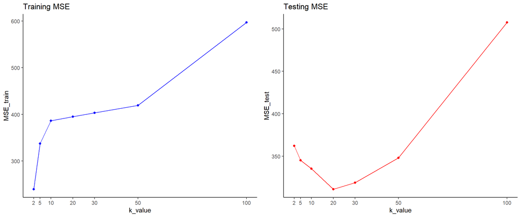

```r
#Plot Training MSE
p1 <- ggplot(data = df_MSE,
             mapping = aes(x = k_value, y = MSE_train))+
  geom_line(color = "blue")+
  geom_point(color = "blue")+
  scale_x_continuous(breaks = c(2, 5, 10, 20, 30, 50, 100))+
  theme(panel.grid.major = element_blank(), panel.grid.minor = element_blank(),
        panel.background = element_blank(), axis.line = element_line(colour = "black"))+
  ggtitle("Training MSE")

#Plot Training MSE
p2 <- ggplot(data = df_MSE,
             mapping = aes(x = k_value, y = MSE_test))+
  geom_line(color = "red")+
  geom_point(color = "red")+
  scale_x_continuous(breaks = c(2, 5, 10, 20, 30, 50, 100))+
  theme(panel.grid.major = element_blank(), panel.grid.minor = element_blank(),
        panel.background = element_blank(), axis.line = element_line(colour = "black"))+
  ggtitle("Testing MSE")

grid.arrange(p1, p2, nrow = 1)
```

**Explain:** with k = 20, the model achieves the lowest MSE and generalizes the best performance. In this case, we see that the MSE values of testing dataset decrease when k increase upto a certain point (k = 20) and then start to increase again for larger values of k. Therefore, the optimal value of k for this data set would be around 20

**(c) Plot the training data, testing data and the best kNN model in the same figure.**

with k = 2, Training MSE is lowest, while with k = 20, Testing MSE is lowest

```r
#Create data frame of predictions with k = 2 for training dataset
predictions_tr2 <- data.frame(
  weight_train = x_train,
  horsepower_train = y_train,
  horsepower_pred = kNN(2, x_train, y_train, x_train)
)
head(predictions_tr2, 5)
```

```
##   weight_train horsepower_train horsepower_pred
## 1         2219               83        72.33333
## 2         3940              150       144.00000
## 3         1937               70        70.00000
## 4         2605               88       101.50000
## 5         2702               96       105.50000
```

```r
#Create data frame of predictions with k = 20 for testing dataset
predictions_te20 <- data.frame(
  weight_test = x_test,
  horsepower_test = y_test,
  horsepower_pred = kNN(20, x_train, y_train, x_test)
)
head(predictions_te20, 5)
```

```
##   weight_test horsepower_test horsepower_pred
## 1        4354             220          169.35
## 2        3563             170          128.85
## 3        3761             150          131.50
## 4        2587              85           94.05
## 5        2130              88           73.95
```

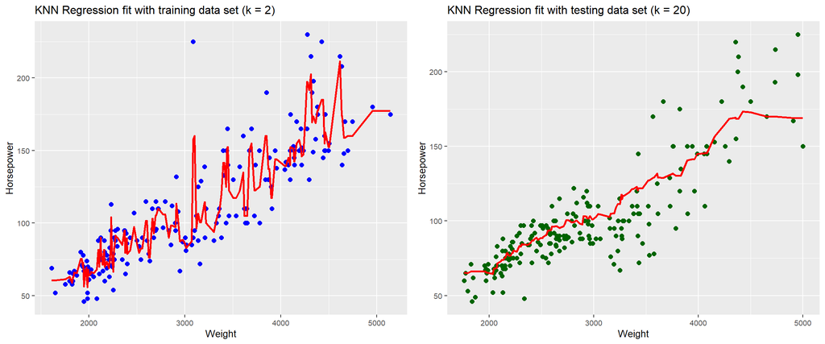

```r
#plot training data set
train_plot <- ggplot(data= predictions_tr2)+
  geom_point(
    mapping = aes(x = weight_train, y = horsepower_train),
    size = 2 , color = "blue")+
  geom_line(
    mapping = aes(x = weight_train, y = horsepower_pred),
    linewidth = 1, color = "red")+
  labs(
    title = "KNN Regression fit with training data set (k = 2)",
    x = "Weight", y = "Horsepower")+
  theme(text = element_text(size=10))

#plot testing data set
test_plot <- ggplot(data= predictions_te20)+
  geom_point(
    mapping = aes(x = weight_test, y = horsepower_test),
    size = 2 , color = "darkgreen")+
  geom_line(
    mapping = aes(x = weight_test, y = horsepower_pred),
    linewidth = 1, color = "red")+
  labs(
    title = "KNN Regression fit with testing data set (k = 20)",
    x = "Weight", y = "Horsepower")+
  theme(text = element_text(size=10))

grid.arrange(train_plot, test_plot, nrow = 1)
```

**(d) Describe the bias-variance trade-off for kNN regression.**

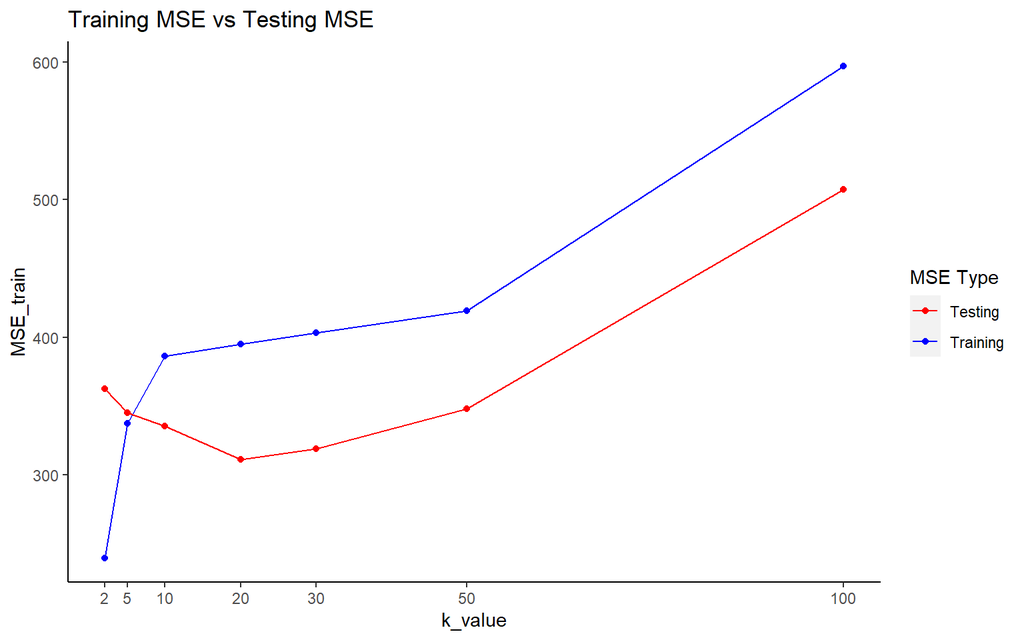

```r
ggplot(data = df_MSE)+
  geom_line(mapping = aes(x = k_value, y = MSE_train, color = "Training"))+
  geom_point(mapping = aes(x = k_value, y = MSE_train, color = "Training"))+
  geom_line(mapping = aes(x = k_value, y = MSE_test, color = "Testing"))+
  geom_point(mapping = aes(x = k_value, y = MSE_test, color = "Testing"))+
  scale_x_continuous(breaks = c(2, 5, 10, 20, 30, 50, 100))+
  scale_color_manual(values = c("red", "blue"), name = "MSE Type", labels = c("Testing", "Training"))+
  theme(panel.grid.major = element_blank(), panel.grid.minor = element_blank(),
        panel.background = element_blank(), axis.line = element_line(colour = "black"),
        legend.position = "right")+
  ggtitle("Training MSE vs Testing MSE")
```